# Practical Machine Learning : Course Project

Horace Cheng

### Executive Summary

The human activity recognition research has traditionally focused on discriminating between different activities, i.e. to predict “which” activity was performed at a specific point in time. This project use the **Weight Lifting Exercises** dataset to investigate “how (well)” an activity was performed by the wearer. The detail information about this dataset can refer to: http://groupware.les.inf.puc-rio.br/har

The goal of this project is to predict the manner in which they did the exercise. This is the **classe** variable in the training set. After building the model and test with the test data, we have the following findings:

- **Pre-processing** dataset is necessary in building models. Initially there are *146* predictors in dataset. After pre-processing, we reduce the number of predictor to *53*.
- `Random Forest` method works very well in this project. The out of sample error is only *0.0024(0.24%)*. However, we still have to do some experiments for other possible candidates to pick up the best choices.
- **Cross Validation** do have a little improvement in the final model. But cross validation will make training time longer. So we need to balance between folds/repeat times and accuracy of the model.

### Pre-processing Data

```r
# load library
library(caret)
```

1. **Reading data**: Read the training data first:

```r
# read data
pml <- read.csv("pml-training.csv", stringsAsFactors = F)
data <- pml[,-(1:5)]
rm(pml)
```

2. **Cleaning data (type transformation)**: We can see some variables should be *number* but read as *char*. So we have to change their type to number:

```r
# some variable is numeric but wrongly read as char
data$kurtosis_roll_belt <- as.numeric(data$kurtosis_roll_belt)
data$kurtosis_picth_belt <- as.numeric(data$kurtosis_picth_belt)
data$skewness_roll_belt <- as.numeric(data$skewness_roll_belt)
data$skewness_roll_belt.1 <- as.numeric(data$skewness_roll_belt.1)
data$max_yaw_belt <- as.numeric(data$max_yaw_belt)
data$min_yaw_belt <- as.numeric(data$min_yaw_belt)
data$kurtosis_roll_arm <- as.numeric(data$kurtosis_roll_arm)
data$kurtosis_picth_arm <- as.numeric(data$kurtosis_picth_arm)
data$kurtosis_yaw_arm <- as.numeric(data$kurtosis_yaw_arm)
data$skewness_roll_arm <- as.numeric(data$skewness_roll_arm)
data$skewness_pitch_arm <- as.numeric(data$skewness_pitch_arm)
data$skewness_yaw_arm <- as.numeric(data$skewness_yaw_arm)
data$kurtosis_roll_dumbbell <- as.numeric(data$kurtosis_roll_dumbbell)
data$kurtosis_picth_dumbbell <- as.numeric(data$kurtosis_picth_dumbbell)
data$skewness_roll_dumbbell <- as.numeric(data$skewness_roll_dumbbell)
data$skewness_pitch_dumbbell <- as.numeric(data$skewness_pitch_dumbbell)
data$max_yaw_dumbbell <- as.numeric(data$max_yaw_dumbbell)
data$min_yaw_dumbbell <- as.numeric(data$min_yaw_dumbbell)
data$kurtosis_roll_forearm <- as.numeric(data$kurtosis_roll_forearm)
data$kurtosis_picth_forearm <- as.numeric(data$kurtosis_picth_forearm)
data$skewness_roll_forearm <- as.numeric(data$skewness_roll_forearm)
data$skewness_pitch_forearm <- as.numeric(data$skewness_pitch_forearm)
data$max_yaw_forearm <- as.numeric(data$max_yaw_forearm)
data$min_yaw_forearm <- as.numeric(data$min_yaw_forearm)
```

3. **Cleaning data (no use variables)**: Some variables with strange or meaningless values, so we remove them from our dataset:

```r
# remove variables with strange or meaningless values:
data <- subset(data, select = -c(kurtosis_yaw_belt, skewness_yaw_belt,
                                 amplitude_yaw_belt, kurtosis_yaw_dumbbell,
                                 skewness_yaw_dumbbell, amplitude_yaw_dumbbell,
                                 kurtosis_yaw_forearm, skewness_yaw_forearm,
                                 amplitude_yaw_forearm))
```

4. **Dummy variables**: Because there is still one char variable, so we create a dummy variable:

```r
# set dummy variables
data$new_window <- as.factor(data$new_window)
data$classe <- as.factor(data$classe)
dummies <- dummyVars(classe ~ ., data = data)
df <- as.data.frame(predict(dummies, newdata = data))
```

5. **Imputing missing values**: We don’t have any information about missing values, so we assume they should be 0:

```r
# impute NA as 0
df[is.na(df)] <- 0
```

6. **Zero- and Near Zero-Variance**: To reduce the number of predictors, we remove some zero- and near zero-variance predictors:

```r
# Zero- and Near Zero-Variance Predictors
nzv <- nearZeroVar(df)
df <- df[, -nzv]
```

### Training the Model

After pre-ocessing, only 53 predictors left in our dataset. So we start training our model.

1. **Data Splitting**: Split data to training set and testing set:

```r
#split to training set and data set
set.seed(99889)
inTrain <- createDataPartition(data$classe, p = 0.75, list=F)
trainingX <- df[inTrain,]
trainingY <- data$classe[inTrain]
testingX <- df[-inTrain,]
testingY <- data$classe[-inTrain]
```

2. **Cross Validation**: we use `repeatedcv` for repeated k-fold cross-validation(repeat 10 times and k = 10).

```r
# use trainControl to control the resampling
# repeated(10 times) K(K=10) fold cross validation
ctrl <- trainControl(method = "repeatedcv", number = 10, repeats = 10, classProbs = TRUE)
```

3. **Training**: Start training by `Random Forest` model. We choose this model by following steps:
- First, this is a classification problem with multiple classes. So the `Multiple Logistic Regression`, `Tree-Based method` and `Support Vector Machine` are 3 possible options we can use.
- Second, we tried 3 Multiple Logistic Regression algorithms: LDA, QDA and GBM. LDA has poor prediction capability(accuracy < 80%). QDA is better in accuracy(around 89%). GBM spent a very long time in training but didn’t do a better job.
- Then we tried Support Vector Machine with linear kernel. It also has poor prediction capability(accuracy < 80%), so we will not use it.
- Finally, we tried Random Forest method. It works very well in prediction capability(accuracy > 99%), so we choose it as our final model.

```r
rfModel <- train(x=trainingX, y=trainingY, method = "rf", trControl = ctrl)
rfModel
```

```
## Random Forest
##
## 14718 samples
##    53 predictor
##     5 classes: 'A', 'B', 'C', 'D', 'E'
##
## No pre-processing
## Resampling: Cross-Validated (10 fold, repeated 10 times)
##
## Summary of sample sizes: 13248, 13246, 13246, 13245, 13246, 13247, ...
##
## Resampling results across tuning parameters:
##
##   mtry  Accuracy  Kappa  Accuracy SD  Kappa SD
##    2    0.995     0.994  0.00223      0.00282
##   27    0.998     0.997  0.00143      0.00180
##   53    0.994     0.993  0.00214      0.00271
##
## Accuracy was used to select the optimal model using  the largest value.
## The final value used for the model was mtry = 27.
```

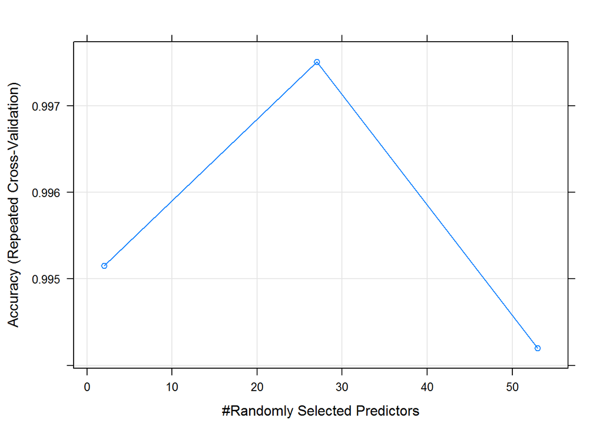

```r
plot(rfModel)
```

### Out of Sample Error

According to the information of the model, in sample error is `1 - 0.998 = 0.002`.

Then we test with the testing set:

```r
rfPred <- predict(rfModel, testingX)
confusionMatrix(rfPred, testingY)
```

```
## Confusion Matrix and Statistics
##
##           Reference
## Prediction    A    B    C    D    E
##          A 1393    0    0    0    0
##          B    1  946    4    0    0
##          C    0    3  851    2    0
##          D    0    0    0  801    0
##          E    1    0    0    1  901
##
## Overall Statistics
##
##                Accuracy : 0.9976
##                  95% CI : (0.9957, 0.9987)
##     No Information Rate : 0.2845
##     P-Value [Acc > NIR] : < 2.2e-16
##
##                   Kappa : 0.9969
##  Mcnemar's Test P-Value : NA
##
## Statistics by Class:
##
##                      Class: A Class: B Class: C Class: D Class: E
## Sensitivity            0.9986   0.9968   0.9953   0.9963   1.0000
## Specificity            1.0000   0.9987   0.9988   1.0000   0.9995
## Pos Pred Value         1.0000   0.9947   0.9942   1.0000   0.9978
## Neg Pred Value         0.9994   0.9992   0.9990   0.9993   1.0000
## Prevalence             0.2845   0.1935   0.1743   0.1639   0.1837
## Detection Rate         0.2841   0.1929   0.1735   0.1633   0.1837
## Detection Prevalence   0.2841   0.1939   0.1746   0.1633   0.1841
## Balanced Accuracy      0.9993   0.9978   0.9970   0.9981   0.9998
```

The accuracy is **0.9976**, so our out of sample error is `1 - 0.9976 = 0.0024`.

### Testing

After building the model, we are ready to test.

First, we read the testing data. We still have to pre-process the data as we did in building the model.

```r
# start testing
pml_test <- read.csv("pml-testing.csv", stringsAsFactors = F)
data_test <- pml_test[,-(1:5)]

data_test$kurtosis_roll_belt <- as.numeric(data_test$kurtosis_roll_belt)
data_test$kurtosis_picth_belt <- as.numeric(data_test$kurtosis_picth_belt)
data_test$skewness_roll_belt <- as.numeric(data_test$skewness_roll_belt)
data_test$skewness_roll_belt.1 <- as.numeric(data_test$skewness_roll_belt.1)
data_test$max_yaw_belt <- as.numeric(data_test$max_yaw_belt)
data_test$min_yaw_belt <- as.numeric(data_test$min_yaw_belt)
data_test$kurtosis_roll_arm <- as.numeric(data_test$kurtosis_roll_arm)
data_test$kurtosis_picth_arm <- as.numeric(data_test$kurtosis_picth_arm)
data_test$kurtosis_yaw_arm <- as.numeric(data_test$kurtosis_yaw_arm)
data_test$skewness_roll_arm <- as.numeric(data_test$skewness_roll_arm)
data_test$skewness_pitch_arm <- as.numeric(data_test$skewness_pitch_arm)
data_test$skewness_yaw_arm <- as.numeric(data_test$skewness_yaw_arm)
data_test$kurtosis_roll_dumbbell <- as.numeric(data_test$kurtosis_roll_dumbbell)
data_test$kurtosis_picth_dumbbell <- as.numeric(data_test$kurtosis_picth_dumbbell)
data_test$skewness_roll_dumbbell <- as.numeric(data_test$skewness_roll_dumbbell)
data_test$skewness_pitch_dumbbell <- as.numeric(data_test$skewness_pitch_dumbbell)
data_test$max_yaw_dumbbell <- as.numeric(data_test$max_yaw_dumbbell)
data_test$min_yaw_dumbbell <- as.numeric(data_test$min_yaw_dumbbell)
data_test$kurtosis_roll_forearm <- as.numeric(data_test$kurtosis_roll_forearm)
data_test$kurtosis_picth_forearm <- as.numeric(data_test$kurtosis_picth_forearm)
data_test$skewness_roll_forearm <- as.numeric(data_test$skewness_roll_forearm)
data_test$skewness_pitch_forearm <- as.numeric(data_test$skewness_pitch_forearm)
data_test$max_yaw_forearm <- as.numeric(data_test$max_yaw_forearm)
data_test$min_yaw_forearm <- as.numeric(data_test$min_yaw_forearm)

# we only need predictors the model needed
df_test <- data_test[, colnames(df)]

# imput NA as 0
df_test[is.na(df_test)] <- 0
```

```r
# predict testing data
answers <- predict(rfModel, df_test)
```